# Bevan Joubert

## Ensemble Techniques Project

```python
# Import all the required packages.
import numpy as np
import pandas as pd
import matplotlib.pyplot as plt
import seaborn as sns

from sklearn import metrics
from sklearn.metrics import confusion_matrix, recall_score, precision_score, f1_score, roc_auc_score, accuracy_score
from sklearn.model_selection import train_test_split
from sklearn.linear_model import LogisticRegression
from sklearn import tree
from sklearn.tree import DecisionTreeClassifier
from sklearn.ensemble import BaggingClassifier
from sklearn.ensemble import RandomForestClassifier
from sklearn.ensemble import AdaBoostClassifier
from sklearn.ensemble import GradientBoostingClassifier

from yellowbrick.classifier import ClassificationReport, ROCAUC

from IPython.core.interactiveshell import InteractiveShell
pd.options.display.float_format = '{:,.2f}'.format
from IPython.core.display import display, HTML
display(HTML("<style>.container { width:90% !important; }</style>"))
pd.set_option('display.max_columns', None)
#pd.set_option('display.precision', 6)
pd.set_option('display.float_format', '{:0.4f}'.format)

from os import system
from IPython.display import Image
```

### Deliverable 1 - Data Exploration

```python
# Import the raw data.
bankData = pd.read_csv("bank-full.csv")
```

#### Data Overview

```python
# Display some of the raw data.
bankData.head(10)
```

|  | age | job | marital | education | default | balance | housing | loan | contact | day | month | duration | campaign | pdays | previous | poutcome | Target |
| --- | --- | --- | --- | --- | --- | --- | --- | --- | --- | --- | --- | --- | --- | --- | --- | --- | --- |
| 0 | 58 | management | married | tertiary | no | 2143 | yes | no | unknown | 5 | may | 261 | 1 | -1 | 0 | unknown | no |
| 1 | 44 | technician | single | secondary | no | 29 | yes | no | unknown | 5 | may | 151 | 1 | -1 | 0 | unknown | no |
| 2 | 33 | entrepreneur | married | secondary | no | 2 | yes | yes | unknown | 5 | may | 76 | 1 | -1 | 0 | unknown | no |
| 3 | 47 | blue-collar | married | unknown | no | 1506 | yes | no | unknown | 5 | may | 92 | 1 | -1 | 0 | unknown | no |
| 4 | 33 | unknown | single | unknown | no | 1 | no | no | unknown | 5 | may | 198 | 1 | -1 | 0 | unknown | no |
| 5 | 35 | management | married | tertiary | no | 231 | yes | no | unknown | 5 | may | 139 | 1 | -1 | 0 | unknown | no |
| 6 | 28 | management | single | tertiary | no | 447 | yes | yes | unknown | 5 | may | 217 | 1 | -1 | 0 | unknown | no |
| 7 | 42 | entrepreneur | divorced | tertiary | yes | 2 | yes | no | unknown | 5 | may | 380 | 1 | -1 | 0 | unknown | no |
| 8 | 58 | retired | married | primary | no | 121 | yes | no | unknown | 5 | may | 50 | 1 | -1 | 0 | unknown | no |
| 9 | 43 | technician | single | secondary | no | 593 | yes | no | unknown | 5 | may | 55 | 1 | -1 | 0 | unknown | no |

```python
# Show the shape of the data.
bankData.shape
```

```
(45211, 17)
```

```python
# Display the datatypes of each feature and null values.
bankData.info()
```

```
<class 'pandas.core.frame.DataFrame'>
RangeIndex: 45211 entries, 0 to 45210
Data columns (total 17 columns):
 #   Column     Non-Null Count  Dtype
---  ------     --------------  -----
 0   age        45211 non-null  int64
 1   job        45211 non-null  object
 2   marital    45211 non-null  object
 3   education  45211 non-null  object
 4   default    45211 non-null  object
 5   balance    45211 non-null  int64
 6   housing    45211 non-null  object
 7   loan       45211 non-null  object
 8   contact    45211 non-null  object
 9   day        45211 non-null  int64
 10  month      45211 non-null  object
 11  duration   45211 non-null  int64
 12  campaign   45211 non-null  int64
 13  pdays      45211 non-null  int64
 14  previous   45211 non-null  int64
 15  poutcome   45211 non-null  object
 16  Target     45211 non-null  object
dtypes: int64(7), object(10)
memory usage: 5.9+ MB
```

```python
# Display the 5 number summary for all the numercal features.
bankData.describe().transpose()
```

|  | count | mean | std | min | 25% | 50% | 75% | max |
| --- | --- | --- | --- | --- | --- | --- | --- | --- |
| age | 45211.0000 | 40.9362 | 10.6188 | 18.0000 | 33.0000 | 39.0000 | 48.0000 | 95.0000 |
| balance | 45211.0000 | 1362.2721 | 3044.7658 | -8019.0000 | 72.0000 | 448.0000 | 1428.0000 | 102127.0000 |
| day | 45211.0000 | 15.8064 | 8.3225 | 1.0000 | 8.0000 | 16.0000 | 21.0000 | 31.0000 |
| duration | 45211.0000 | 258.1631 | 257.5278 | 0.0000 | 103.0000 | 180.0000 | 319.0000 | 4918.0000 |
| campaign | 45211.0000 | 2.7638 | 3.0980 | 1.0000 | 1.0000 | 2.0000 | 3.0000 | 63.0000 |
| pdays | 45211.0000 | 40.1978 | 100.1287 | -1.0000 | -1.0000 | -1.0000 | -1.0000 | 871.0000 |
| previous | 45211.0000 | 0.5803 | 2.3034 | 0.0000 | 0.0000 | 0.0000 | 0.0000 | 275.0000 |

#### Data Overview Observations:

- It does not seem that there are any missing or incorrect values in the dataset, further analysis will clarify if this is true.

#### Univariate Analysis - Categorical Data

```python
# Calculate Proportion of Yes and No values for Target
bankData['Target'].value_counts(normalize=True)
```

```
no    0.8830
yes   0.1170
Name: Target, dtype: float64
```

```python
# See how many unique values each feature has.
bankData.nunique()
```

```
age            77
job            12
marital         3
education       4
default         2
balance      7168
housing         2
loan            2
contact         3
day            31
month          12
duration     1573
campaign       48
pdays         559
previous       41
poutcome        4
Target          2
dtype: int64
```

```
                job
blue-collar    9732
management     9458
technician     7597
admin.         5171
services       4154
retired        2264
self-employed  1579
entrepreneur   1487
unemployed     1303
housemaid      1240
student         938
unknown         288
```

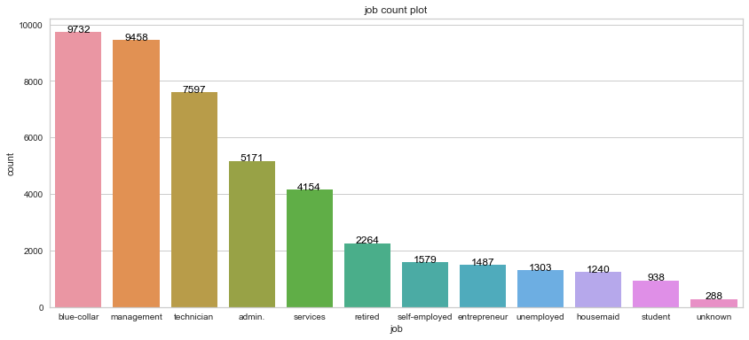

```
          marital
married     27214
single      12790
divorced     5207
```

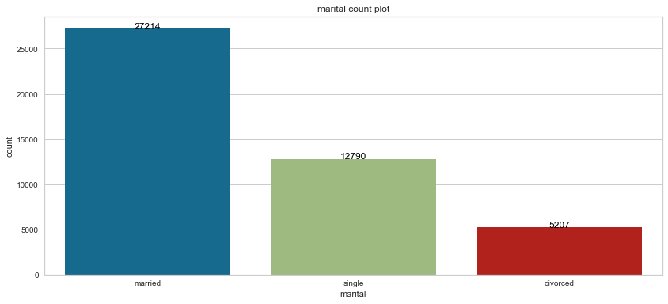

```
           education
secondary      23202
tertiary       13301
primary         6851
unknown         1857
```

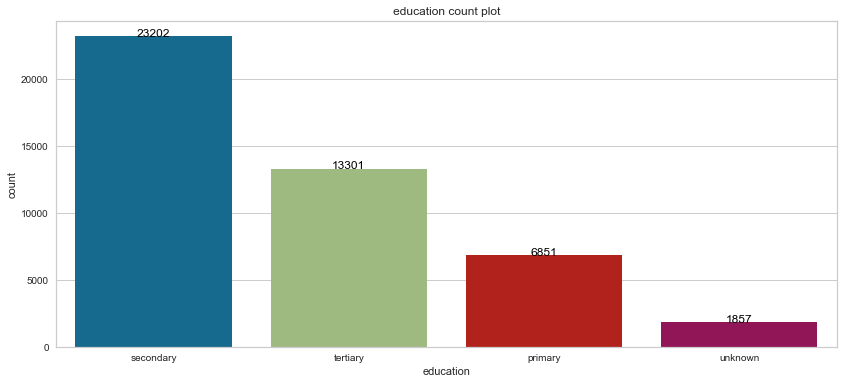

```
     default
no     44396
yes      815
```

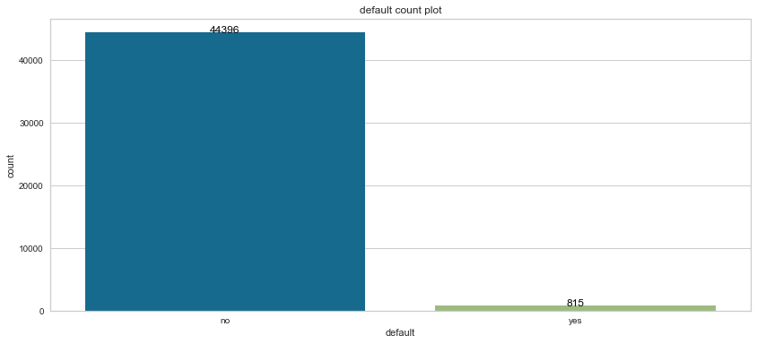

```
     housing
yes    25130
no     20081
```

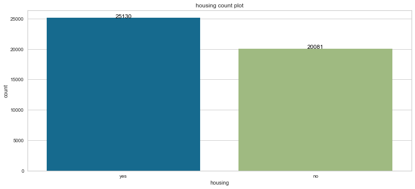

```
      loan
no   37967
yes   7244
```

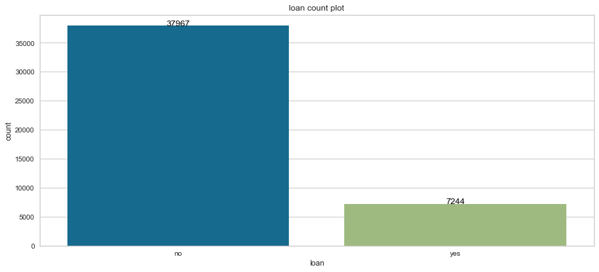

```
           contact
cellular     29285
unknown      13020
telephone     2906
```

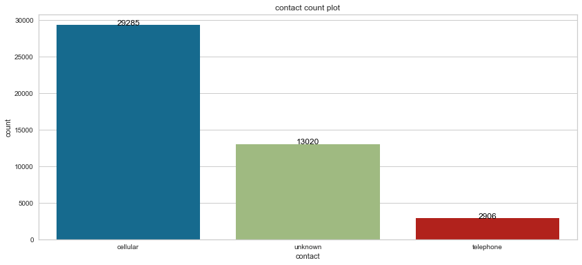

```
     month
may  13766
jul   6895
aug   6247
jun   5341
nov   3970
apr   2932
feb   2649
jan   1403
oct    738
sep    579
mar    477
dec    214
```

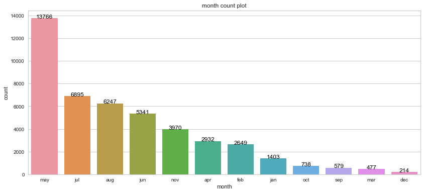

```
         poutcome
unknown     36959
failure      4901
other        1840
success      1511
```

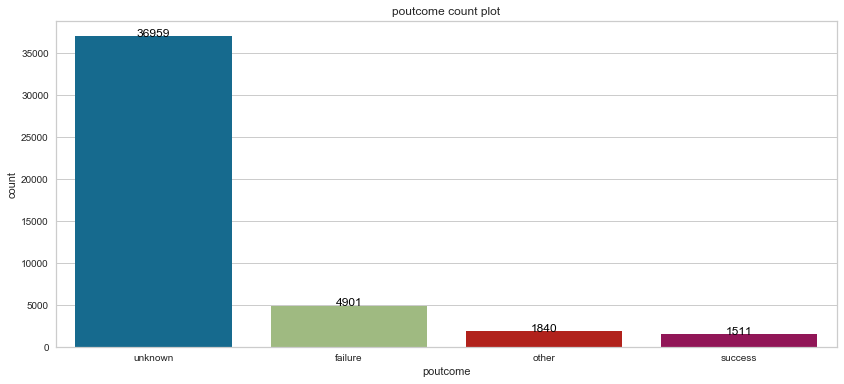

```
     Target
no    39922
yes    5289
```

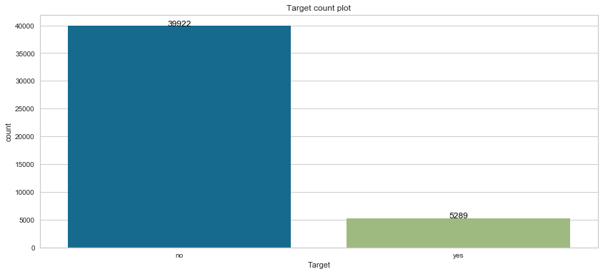

```python
# Show the value counts for each categorical feature
for column in bankData:
    if (bankData[column].dtype == "object"):
        temp_df = pd.DataFrame(bankData[column].value_counts().sort_values(ascending=False))
        print(temp_df)
        plt.figure(figsize=(14,6))
        ax0 = sns.barplot(x=temp_df.index, y=temp_df[column])
        ax0.set_title(str(column) + " count plot")
        ax0.set_xlabel(column)
        ax0.set_ylabel("count")
        count=0
        for index, row in temp_df.iterrows():
            ax0.text(count, row[column], row[column], color='black', ha="center")
            count +=  1
        plt.show()
```

#### Univariate Categorical Feature Observations

- No missing values, values which would have been missing are already recorded as unknown.
- It does not seem useful to convert any of the categorical features to a ranked format, maybe 'eduaction', but then what does one doe with the 'unknown' value. It would only make sense to rank the 'default', 'housing' and 'loan' features, but they will be converted to 1 and 0 anyway which has the same effect.

#### Univariate Analysis - Numerical Data

```python
# Which columns have zeros and how many.
bankData.isin([0]).sum()
```

```
age              0
job              0
marital          0
education        0
default          0
balance       3514
housing          0
loan             0
contact          0
day              0
month            0
duration         3
campaign         0
pdays            0
previous     36954
poutcome         0
Target           0
dtype: int64
```

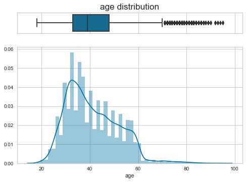

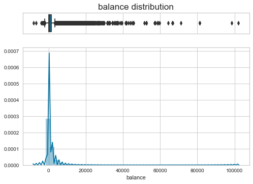

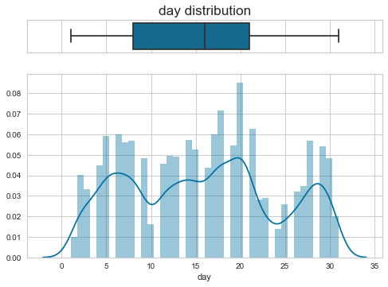

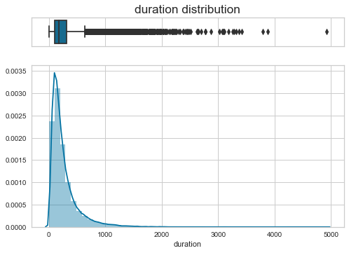

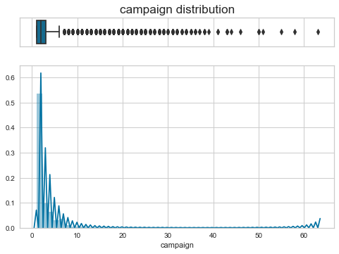

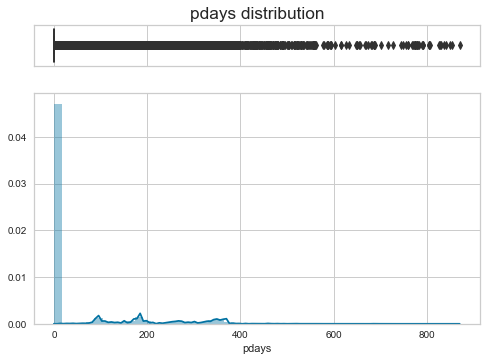

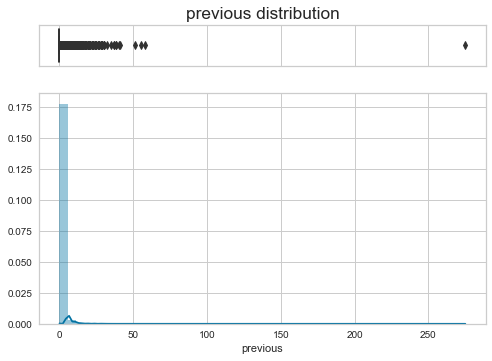

```python
# Look at the distributions of the numerical data in the form of boxplots and histograms.
for column in bankData:
    if (bankData[column].dtype == "int64"):
        # Cut the window in 2 parts
        f, (ax_box, ax_hist) = plt.subplots(2, sharex=True, gridspec_kw={"height_ratios": (.15, .85)})
        ax_box.set_title(column + " distribution", size='x-large')
        # Add a graph in each part
        sns.boxplot(bankData[column], ax=ax_box)
        sns.distplot(bankData[column], ax=ax_hist)

        # Remove x axis name for the boxplot
        ax_box.set(xlabel='')
```

#### Univariate Numerical Feature Observations:

- No missing or incorrect value shere, numerical features which contain zeros are of such a type that a zero is not an incorrect value.
- There are no values which seem out of a plausable range.
- The value most likely to be out of practical range is a value oif 275 for the 'previous' feature, however, it is quite possible that the value could be so high. The fact that it is so high above all of the other values makes it seem false though, but it is only one value and probably won't have much of an effect.
- There is a lot of data which fallas out of the 25% to 75% range, however these values are still in a reasonable range for the item which they present. Are they then still considered outliers?
- I don't see a point in capping any of these features or replacing the streme values with mean or mode. since these avalues all represent real world data, the model must learn to deal with them in order to be practical in the real world. Altering this data might make the model more accurate for this dataset, but will result in innaccuracy with new data.
- Taking the log of the 'duration' feature might distribute it more normally, but would that really achieve anything?

#### Multivariate Analysis

```
Target           no   yes  Total  % Success
job
student         669   269    938    28.6800
retired        1748   516   2264    22.7900
unemployed     1101   202   1303    15.5000
management     8157  1301   9458    13.7600
admin.         4540   631   5171    12.2000
self-employed  1392   187   1579    11.8400
unknown         254    34    288    11.8100
technician     6757   840   7597    11.0600
services       3785   369   4154     8.8800
housemaid      1131   109   1240     8.7900
entrepreneur   1364   123   1487     8.2700
blue-collar    9024   708   9732     7.2700
```

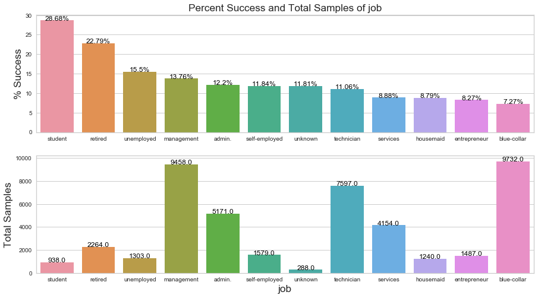

```
Target       no   yes  Total  % Success
marital
single    10878  1912  12790    14.9500
divorced   4585   622   5207    11.9500
married   24459  2755  27214    10.1200
```

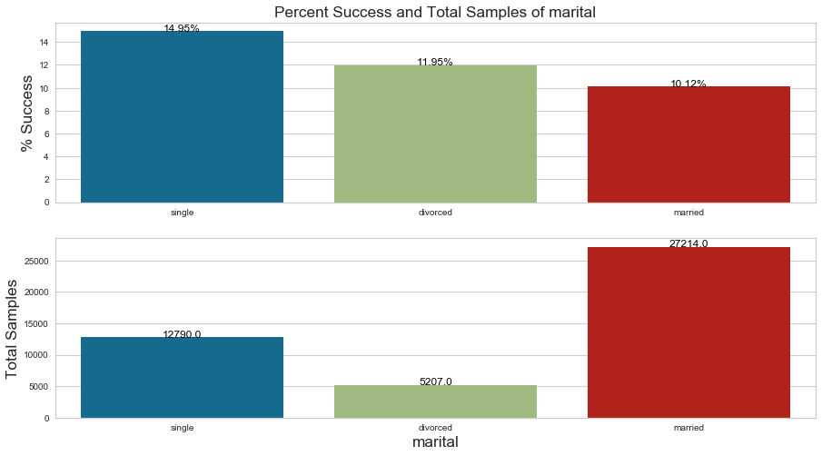

```
Target        no   yes  Total  % Success
education
tertiary   11305  1996  13301    15.0100
unknown     1605   252   1857    13.5700
secondary  20752  2450  23202    10.5600
primary     6260   591   6851     8.6300
```

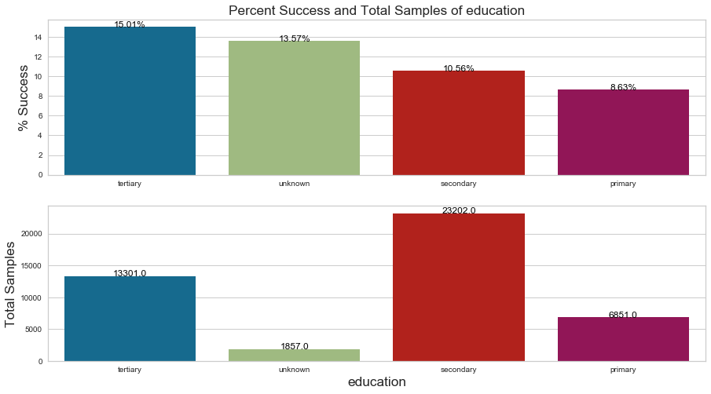

```
Target      no   yes  Total  % Success
default
no       39159  5237  44396    11.8000
yes        763    52    815     6.3800
```

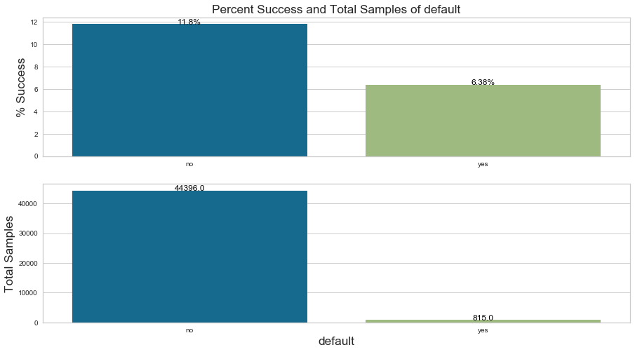

```
Target      no   yes  Total  % Success
housing
no       16727  3354  20081    16.7000
yes      23195  1935  25130     7.7000
```

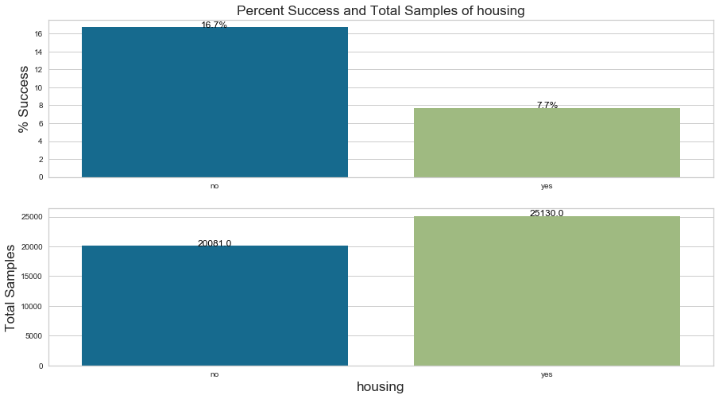

```
Target     no   yes  Total  % Success
loan
no      33162  4805  37967    12.6600
yes      6760   484   7244     6.6800
```

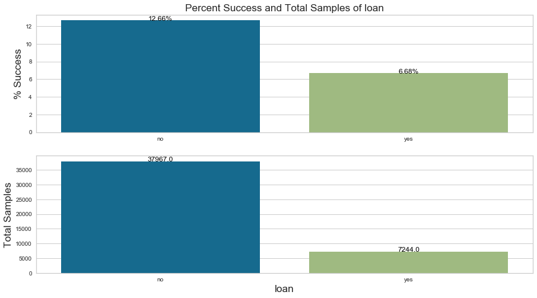

```
Target        no   yes  Total  % Success
contact
cellular   24916  4369  29285    14.9200
telephone   2516   390   2906    13.4200
unknown    12490   530  13020     4.0700
```

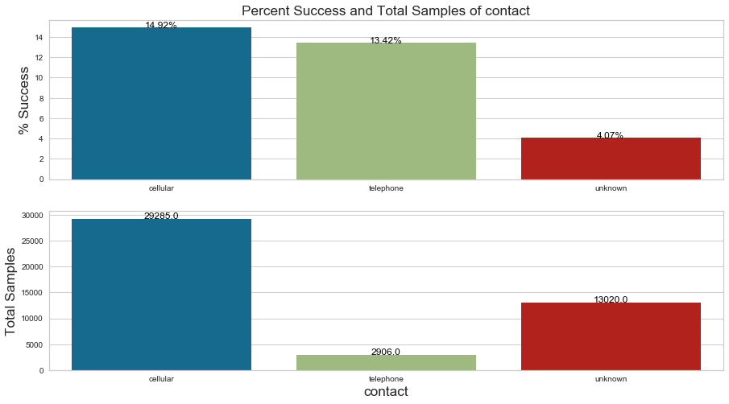

```
Target     no  yes  Total  % Success
month
mar       229  248    477    51.9900
dec       114  100    214    46.7300
sep       310  269    579    46.4600
oct       415  323    738    43.7700
apr      2355  577   2932    19.6800
feb      2208  441   2649    16.6500
aug      5559  688   6247    11.0100
jun      4795  546   5341    10.2200
nov      3567  403   3970    10.1500
jan      1261  142   1403    10.1200
jul      6268  627   6895     9.0900
may     12841  925  13766     6.7200
```

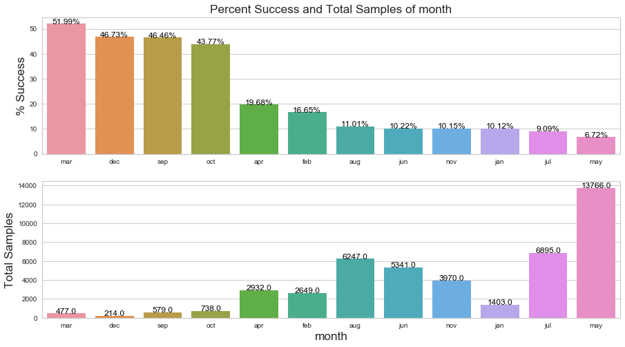

```
Target       no   yes  Total  % Success
poutcome
success     533   978   1511    64.7300
other      1533   307   1840    16.6800
failure    4283   618   4901    12.6100
unknown   33573  3386  36959     9.1600
```

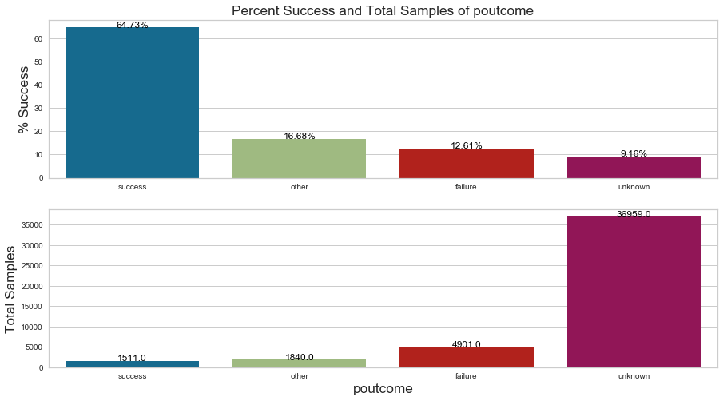

```python
# Look for any relationship between the categorical features and the percentage of successful product subscription.
# Also tak total samples into account beacause data with a low number of samples could be biased.
count=0
for column in bankData.drop(columns=['Target']):
    if (bankData[column].dtype == "object"):
        temp_df = pd.crosstab(bankData[column], bankData["Target"])
        temp_df['Total'] = (temp_df['no'].add(temp_df['yes']))
        temp_df['% Success'] = (round(temp_df['yes'].div(temp_df['no'].add(temp_df['yes']))*100,2))
        temp_df_sorted = temp_df.sort_values(by='% Success', ascending=False)
        print(temp_df_sorted)

        f, (ax_per, ax_tot) = plt.subplots(2, gridspec_kw={"height_ratios": (.5, .5)}, figsize=(15,8))
        sns.barplot(x=temp_df_sorted.index, y=temp_df_sorted['% Success'], ax=ax_per)
        sns.barplot(x=temp_df_sorted.index, y=temp_df_sorted['Total'], ax=ax_tot)
        ax_per.set_title("Percent Success and Total Samples of "+column, size='x-large')
        ax_per.set_xlabel("")
        ax_per.set_xticklabels(temp_df_sorted.index)
        ax_per.set_ylabel("% Success", size='x-large')
        ax_tot.set_xlabel(column, size='x-large')
        ax_tot.set_xticklabels(temp_df_sorted.index)
        ax_tot.set_ylabel("Total Samples", size='x-large')
        count = 0
        for index, row in temp_df_sorted.iterrows():
            ax_per.text(count, row['% Success'], str(row['% Success'])+'%', color='black', ha="center")
            ax_tot.text(count, row['Total'], str(row['Total']), color='black', ha="center")
            count +=  1
        plt.show()
```

#### Categorical Feature Relation to Target

- For some reason students, retirees and unemployed people have the highest success percentages, these are the people who are supposed to have the least amount of money. However, looking at the value counts, these 3 job categories also have relatively low numbers, therefore the high percentages may just be due to the low number of samples.
- Single people and people with tertiary education show higher percentages of accpeting the offer, this is also interesting because both these categories have mid range value counts within their respective features.
- People who have not defaulted on debt and people who currently have no debt have a higher percentage of accepting the offer, this is quite obvious, since such people are more likely to have spare money to invest.
- People who accepted the previous offer are quite likely to accept the new offer.
- Notice that the months with the highest success percentage are also the months with the lowest number of samples.
- The rest of the features are quite randomly associated to success percentage.

```python
# Look for any correlation between numerical features.
# Print the columns of the dataset again for reference.
bankData.head(3)
```

|  | age | job | marital | education | default | balance | housing | loan | contact | day | month | duration | campaign | pdays | previous | poutcome | Target |
| --- | --- | --- | --- | --- | --- | --- | --- | --- | --- | --- | --- | --- | --- | --- | --- | --- | --- |
| 0 | 58 | management | married | tertiary | no | 2143 | yes | no | unknown | 5 | may | 261 | 1 | -1 | 0 | unknown | no |
| 1 | 44 | technician | single | secondary | no | 29 | yes | no | unknown | 5 | may | 151 | 1 | -1 | 0 | unknown | no |
| 2 | 33 | entrepreneur | married | secondary | no | 2 | yes | yes | unknown | 5 | may | 76 | 1 | -1 | 0 | unknown | no |

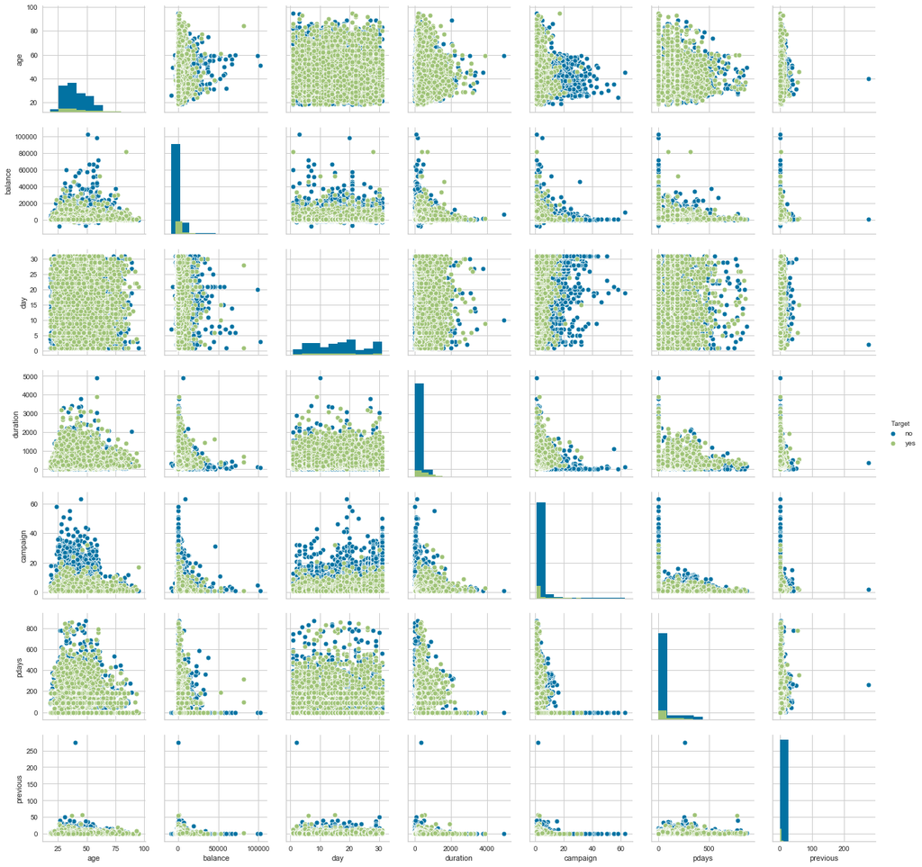

```python
# Show the pairplot.
sns.pairplot(bankData, hue="Target", diag_kind='hist')
# Pairplot is only using numerical data.
```

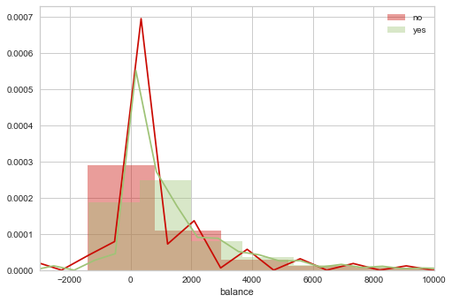

```python
# How is the bank balance related to the offer acceptance.
ax1 = sns.distplot(bankData[bankData['Target']=='no']['balance'],color='r',label='no')
sns.distplot(bankData[bankData['Target']=='yes']['balance'],color='g',label='yes')
ax1.set_xlim(-3000, 10000)
plt.legend()
plt.show()
```

```python
# Looks like the poeple who accept the offer hav a slightly higher bank balance, but not significantly.
```

```python
# Look for any correlation between the features.
bankData.corr()
```

|  | age | balance | day | duration | campaign | pdays | previous |
| --- | --- | --- | --- | --- | --- | --- | --- |
| age | 1.0000 | 0.0978 | -0.0091 | -0.0046 | 0.0048 | -0.0238 | 0.0013 |
| balance | 0.0978 | 1.0000 | 0.0045 | 0.0216 | -0.0146 | 0.0034 | 0.0167 |
| day | -0.0091 | 0.0045 | 1.0000 | -0.0302 | 0.1625 | -0.0930 | -0.0517 |
| duration | -0.0046 | 0.0216 | -0.0302 | 1.0000 | -0.0846 | -0.0016 | 0.0012 |
| campaign | 0.0048 | -0.0146 | 0.1625 | -0.0846 | 1.0000 | -0.0886 | -0.0329 |
| pdays | -0.0238 | 0.0034 | -0.0930 | -0.0016 | -0.0886 | 1.0000 | 0.4548 |
| previous | 0.0013 | 0.0167 | -0.0517 | 0.0012 | -0.0329 | 0.4548 | 1.0000 |

#### Pairplot Observations

- The balance distribution of those who accept the offer is slightly higher overall, but by an insignificant amount.

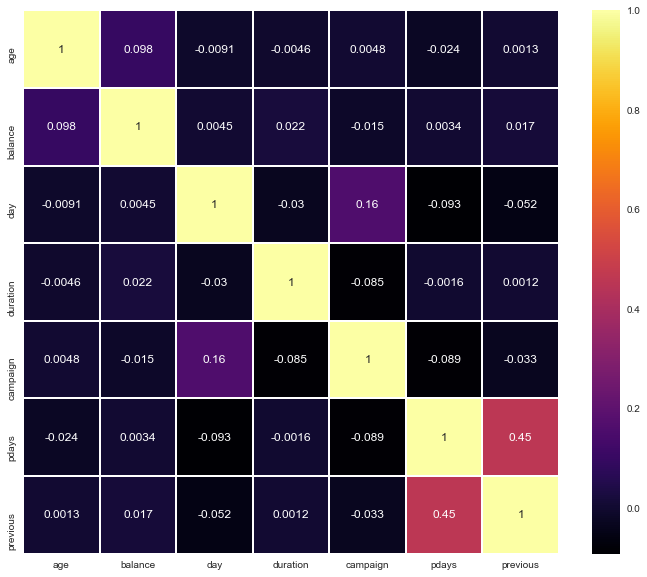

```python
# Represent the correlation visually.
plt.figure(figsize=(12,10))
sns.heatmap(bankData.corr(), annot=True, linewidth=1, cmap='inferno')
```

#### Corelation

There is very little correlation between features.

```python
# A strange observation was made earlier that students, retirees and unemplyed persons have high success percentages.
# Have a look at the mean balance per job category.
balanceData = pd.DataFrame(bankData.groupby(by='job')['balance'].mean().sort_values(ascending=False))
balanceData
```

| job | balance |
| --- | --- |
| retired | 1984.2151 |
| unknown | 1772.3576 |
| management | 1763.6168 |
| self-employed | 1647.9709 |
| unemployed | 1521.7460 |
| entrepreneur | 1521.4701 |
| housemaid | 1392.3952 |
| student | 1388.0608 |
| technician | 1252.6321 |
| admin. | 1135.8389 |
| blue-collar | 1078.8267 |
| services | 997.0881 |

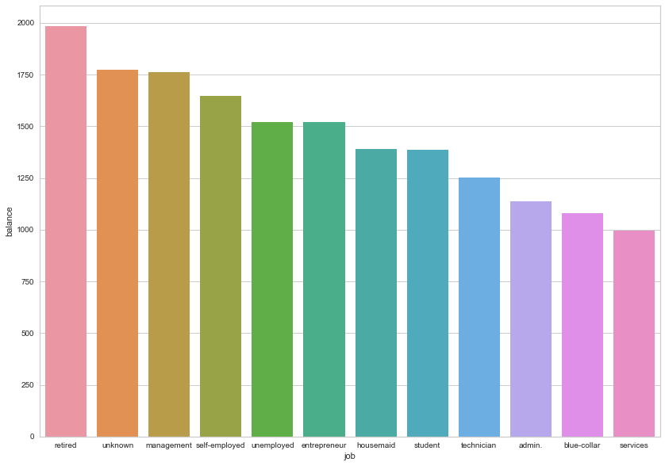

```python
plt.figure(figsize=(14,10))
sns.barplot(x=balanceData.index, y=balanceData['balance'])
```

```python
bankData.groupby(by='job')['balance'].describe()
```

| job | count | mean | std | min | 25% | 50% | 75% | max |
| --- | --- | --- | --- | --- | --- | --- | --- | --- |
| admin. | 5171.0000 | 1135.8389 | 2641.9627 | -1601.0000 | 63.0000 | 396.0000 | 1203.0000 | 64343.0000 |
| blue-collar | 9732.0000 | 1078.8267 | 2240.5232 | -8019.0000 | 55.0000 | 388.0000 | 1203.0000 | 66653.0000 |
| entrepreneur | 1487.0000 | 1521.4701 | 4153.4426 | -2082.0000 | 44.5000 | 352.0000 | 1341.0000 | 59649.0000 |
| housemaid | 1240.0000 | 1392.3952 | 2984.6921 | -1941.0000 | 57.7500 | 406.0000 | 1382.7500 | 45141.0000 |
| management | 9458.0000 | 1763.6168 | 3822.9656 | -6847.0000 | 98.0000 | 572.0000 | 1825.0000 | 102127.0000 |
| retired | 2264.0000 | 1984.2151 | 4397.0442 | -1598.0000 | 164.5000 | 787.0000 | 2309.0000 | 81204.0000 |
| self-employed | 1579.0000 | 1647.9709 | 3684.2596 | -3313.0000 | 120.0000 | 526.0000 | 1603.5000 | 52587.0000 |
| services | 4154.0000 | 997.0881 | 2164.4935 | -2122.0000 | 35.0000 | 339.5000 | 1071.7500 | 57435.0000 |
| student | 938.0000 | 1388.0608 | 2441.7035 | -679.0000 | 148.2500 | 502.0000 | 1579.7500 | 24025.0000 |
| technician | 7597.0000 | 1252.6321 | 2548.5440 | -2827.0000 | 61.0000 | 421.0000 | 1327.0000 | 45248.0000 |
| unemployed | 1303.0000 | 1521.7460 | 3144.6668 | -1270.0000 | 94.0000 | 529.0000 | 1603.5000 | 44134.0000 |
| unknown | 288.0000 | 1772.3576 | 2970.2886 | -295.0000 | 170.7500 | 677.0000 | 2165.5000 | 19706.0000 |

#### Success Percentage Among Job Categories

- The retired job category has the highest mean balance and they are at a stage where they need to make safe investments, so it makes sense that they have a high percentage of offer acceptance.
- The student and unemployed categories have mid-range mean balances, which I would say is quite strange, unless these are trust fund babies and spouses of wealthy people respectively.
- It is also worthy to note from the univariate analysis that the number of samples form the retired, student and unemployed categories are quite low compared to the total number of samples. Therefore, it may just be sheer chance that the success percentage for these categories are high. One might find that the success percentage drops as the sample numbers for these categories increases.

### Deliverable 2 - Data Preparation

```python
bankData_p = bankData.copy() # _p suffix for prepared.
```

```python
# Drop some columns, later we can add them back to see their effect.
droplist=[]
droplist.append('day') # The day column is randomly distributed and should have no effect on the outcome.

# Month is an interesting feature. From the univariate analysis it can be seen that sample numbers are not evenly
# distributed over the months. Furthermore, it can be seen that the months which have the lowest number of samples
# have the highest success percentages. Therefore, I think month the month column must be ommitted.
# I would think that month could be important, as people's financial state do change throughout the year and they are
# more likely to invest at certain times, but first the samples per month should be equalised.
droplist.append('month')

# drop the droplist
bankData_p.drop(droplist, axis='columns', inplace=True)
```

```python
# Convert all 'object' data types to 'category' datatypes.
# Make a copy od bankData, keep the original.
for column in bankData_p:
    if(bankData[column].dtype == 'object'):
        bankData_p[column] = bankData_p[column].astype('category')

bankData_p.dtypes
```

```
age             int64
job          category
marital      category
education    category
default      category
balance         int64
housing      category
loan         category
contact      category
duration        int64
campaign        int64
pdays           int64
previous        int64
poutcome     category
Target       category
dtype: object
```

```python
# Replace all 'yes' and 'no' values with 1 and 0 respectively.
replaceDict = {
                    "default":  {"no": 0, "yes": 1},
                    "housing":  {"no": 0, "yes": 1},
                    "loan":     {"no": 0, "yes": 1},
                    "Target":   {"no": 0, "yes": 1},
                }
bankData_p.replace(replaceDict, inplace=True)
bankData_p.head(5)
```

|  | age | job | marital | education | default | balance | housing | loan | contact | duration | campaign | pdays | previous | poutcome | Target |
| --- | --- | --- | --- | --- | --- | --- | --- | --- | --- | --- | --- | --- | --- | --- | --- |
| 0 | 58 | management | married | tertiary | 0 | 2143 | 1 | 0 | unknown | 261 | 1 | -1 | 0 | unknown | 0 |
| 1 | 44 | technician | single | secondary | 0 | 29 | 1 | 0 | unknown | 151 | 1 | -1 | 0 | unknown | 0 |
| 2 | 33 | entrepreneur | married | secondary | 0 | 2 | 1 | 1 | unknown | 76 | 1 | -1 | 0 | unknown | 0 |
| 3 | 47 | blue-collar | married | unknown | 0 | 1506 | 1 | 0 | unknown | 92 | 1 | -1 | 0 | unknown | 0 |
| 4 | 33 | unknown | single | unknown | 0 | 1 | 0 | 0 | unknown | 198 | 1 | -1 | 0 | unknown | 0 |

```python
# One-hot encode the remainder of the categorical data.
# This is only neccessary for the logistic regression model.
# _lr suffix for logistic regression.
bankData_p = pd.get_dummies(bankData_p, drop_first=True)
bankData_p.head()
```

|  | age | default | balance | housing | loan | duration | campaign | pdays | previous | Target | job_blue-collar | job_entrepreneur | job_housemaid | job_management | job_retired | job_self-employed | job_services | job_student | job_technician | job_unemployed | job_unknown | marital_married | marital_single | education_secondary | education_tertiary | education_unknown | contact_telephone | contact_unknown | poutcome_other | … |
| --- | --- | --- | --- | --- | --- | --- | --- | --- | --- | --- | --- | --- | --- | --- | --- | --- | --- | --- | --- | --- | --- | --- | --- | --- | --- | --- | --- | --- | --- | --- |
| 0 | 58 | 0 | 2143 | 1 | 0 | 261 | 1 | -1 | 0 | 0 | 0 | 0 | 0 | 1 | 0 | 0 | 0 | 0 | 0 | 0 | 0 | 1 | 0 | 0 | 1 | 0 | 0 | 1 | 0 | … |
| 1 | 44 | 0 | 29 | 1 | 0 | 151 | 1 | -1 | 0 | 0 | 0 | 0 | 0 | 0 | 0 | 0 | 0 | 0 | 1 | 0 | 0 | 0 | 1 | 1 | 0 | 0 | 0 | 1 | 0 | … |
| 2 | 33 | 0 | 2 | 1 | 1 | 76 | 1 | -1 | 0 | 0 | 0 | 1 | 0 | 0 | 0 | 0 | 0 | 0 | 0 | 0 | 0 | 1 | 0 | 1 | 0 | 0 | 0 | 1 | 0 | … |
| 3 | 47 | 0 | 1506 | 1 | 0 | 92 | 1 | -1 | 0 | 0 | 1 | 0 | 0 | 0 | 0 | 0 | 0 | 0 | 0 | 0 | 0 | 1 | 0 | 0 | 0 | 1 | 0 | 1 | 0 | … |
| 4 | 33 | 0 | 1 | 0 | 0 | 198 | 1 | -1 | 0 | 0 | 0 | 0 | 0 | 0 | 0 | 0 | 0 | 0 | 0 | 0 | 1 | 0 | 1 | 0 | 0 | 1 | 0 | 1 | 0 | … |

```python
bankData_p.shape
```

```
(45211, 31)
```

```python
# Split the data into dependent and independent vriables.
X = bankData_p.drop('Target', axis='columns')
y = bankData_p['Target']

# Split the data into a testing and Training group.
X_train, X_test, y_train, y_test = train_test_split(X, y, test_size=0.3, random_state=5)
```